# Assignment 1: Compression of a **YCbCr** colored image

## Introduction

The following notebook collects my solution to compress a custom colored image. In particular I provided to blurr the various *YCbCr* channels following the assignment instructions.

For the implementation of the exercise I used theese libraries and packages.

```python
import pandas as pd
import numpy as np
from matplotlib import pyplot as plt
import sys

# Image Management
from skimage import io # Input/Output
from skimage import transform # Geometric Transformation
from skimage import filters # Local Processing
from skimage import color # Color-Space Management

# Impostazione dimensione di visualizzazioni delle immagini
# Setting image dimensions in visualization
plt.rcParams['figure.figsize'] = [15,5] # larghezza, altezza
```

```python
# Image Import
im = io.imread('/path/to/led.jpg')
im.shape
```

```
(4608, 3072, 3)
```

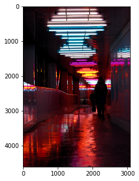

```python
plt.imshow(im)
```

The chosen image has the dimension $(4608,3072)$ and it is in *RGB* color-space.

```python
# Convertion from RGB to YCbCr
im_ycbcr = color.rgb2ycbcr(im)
im_ycbcr.shape
```

```
(4608, 3072, 3)
```

As foreseeable, the color-space conversion of the image doesn't modify its dimension.

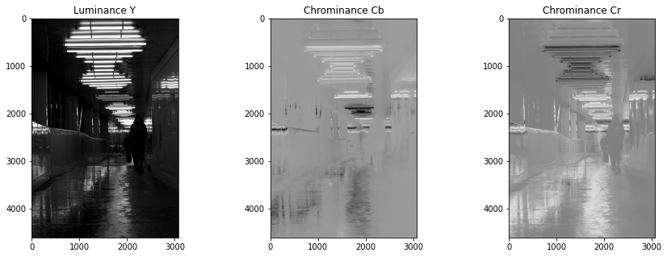

```python
# Subplots of the channels Y - Cb - Cr
plt.subplot(1,3,1); plt.imshow(im_ycbcr[:,:,0], cmap='gray'); plt.title('Luminance Y')
plt.subplot(1,3,2); plt.imshow(im_ycbcr[:,:,1], cmap='gray'); plt.title('Chrominance Cb')
plt.subplot(1,3,3); plt.imshow(im_ycbcr[:,:,2], cmap='gray'); plt.title('Chrominance Cr')
```

## Transformation with **Gaussian** Filter

### Filter on Y channel (**Luma**)

```python
im_filtered = im_ycbcr.copy()
```

As first transformation I applied a Gaussian filter on the Luma channel Y of the image `im_ycbcr`.

To verify the behaviour of different standard deviations of the filter's kernel, I tested 3 $σ$ as follows:

- `sigma1 = (5,5)`
- `sigma2 = (50,50)`
- `sigma1 = (5,50)`

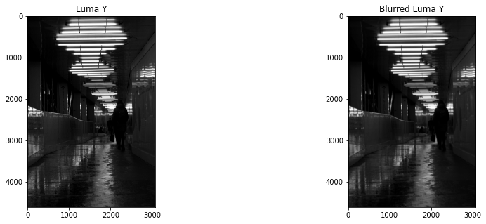

```python
sigma1 = (5,5)

# Gaussian Filter with sd = 5 for both axes
im_filtered[:,:,0] = filters.gaussian(im_ycbcr[:,:,0], sigma1, truncate=3.5,
                                      multichannel=True)

# Subplots comparing original and blurred image
plt.subplot(1,2,1); plt.imshow(im_ycbcr[:,:,0], cmap='gray')
plt.title('Luma Y')
plt.subplot(1,2,2); plt.imshow(im_filtered[:,:,0], cmap='gray')
plt.title('Blurred Luma Y')
```

Because $σ_1$ is not a value too high, the effect deriving from the transformation it's an image very close to the original one. So I decided to set a standard deviation much higher.

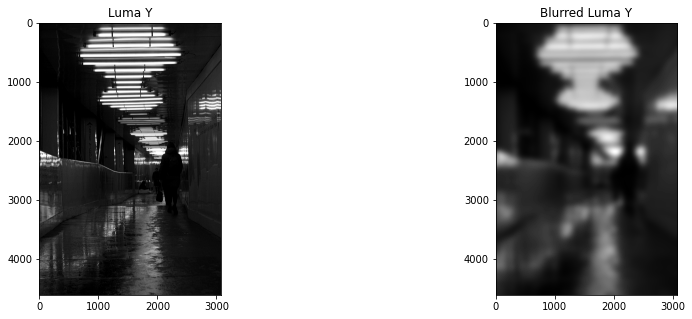

```python
im_filtered_y = im_ycbcr.copy()
sigma2 = (50,50)

# Gaussian Filter with sd = 50 for both axes
im_filtered_y[:,:,0] = filters.gaussian(im_ycbcr[:,:,0], sigma2, truncate=3.5,
                                      multichannel=True)

# Subplots comparing original and blurred image
plt.subplot(1,2,1); plt.imshow(im_ycbcr[:,:,0], cmap='gray')
plt.title('Luma Y')
plt.subplot(1,2,2); plt.imshow(im_filtered_y[:,:,0], cmap='gray')
plt.title('Blurred Luma Y')
```

Lastly I tried to assign some different values of $\sigma$ for each axis.

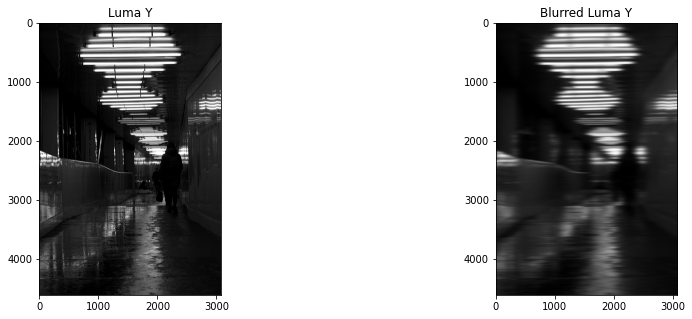

```python
sigma3 = (5,50)

# Gaussian Filter with sd_x = 5 and sd_y = 50
im_filtered[:,:,0] = filters.gaussian(im_ycbcr[:,:,0], sigma3, truncate=3.5,
                                      multichannel=True)

# Subplots comparing original and blurred image
plt.subplot(1,2,1); plt.imshow(im_ycbcr[:,:,0], cmap='gray')
plt.title('Luma Y')
plt.subplot(1,2,2); plt.imshow(im_filtered[:,:,0], cmap='gray')
plt.title('Blurred Luma Y')
```

The output image is less blurred than the previous one but it present a "rough" effect due to the differences in $\sigma$.

### Filter on Cb channel (Blue **Chrominance**)

```python
im_filtered = im_ycbcr.copy()
```

The Gaussian filter used in the previous paragraph to transform the Y channel, I provided to apply it also to the blue chrominance channel Cb. I tested the same values of sigma (`sigma1 = (5,5)`, `sigma2 = (50,50)` and `sigma1 = (5,50)`) for the kernel

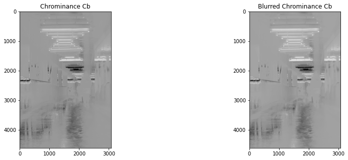

```python
## sigma1 = (5,5) ##

# Gaussian Filter with sd = 5 for both axes
im_filtered[:,:,1] = filters.gaussian(im_ycbcr[:,:,1], sigma1, truncate=3.5,
                                      multichannel=True)

# Subplots comparing original and blurred image on Cb channel
plt.subplot(1,2,1); plt.imshow(im_ycbcr[:,:,1], cmap='gray')
plt.title('Chrominance Cb')
plt.subplot(1,2,2); plt.imshow(im_filtered[:,:,1], cmap='gray')
plt.title('Blurred Chrominance Cb')
```

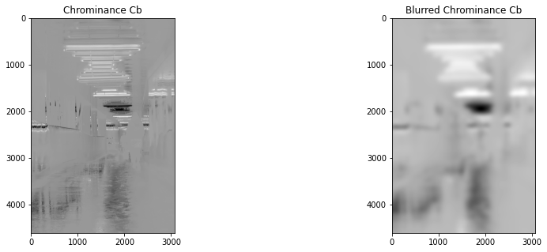

```python
im_filtered_cb = im_ycbcr.copy()
## sigma2 = (50,50) ##

# Gaussian Filter with sd = 50 for both axes
im_filtered_cb[:,:,1] = filters.gaussian(im_ycbcr[:,:,1], sigma2, truncate=3.5,
                                      multichannel=True)

# Subplots comparing original and blurred image on Cb channel
plt.subplot(1,2,1); plt.imshow(im_ycbcr[:,:,1], cmap='gray')
plt.title('Chrominance Cb')
plt.subplot(1,2,2); plt.imshow(im_filtered_cb[:,:,1], cmap='gray')
plt.title('Blurred Chrominance Cb')
```

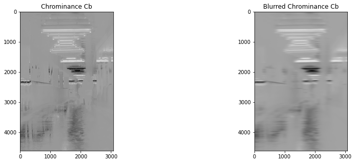

```python
## sigma3 = (5,50) ##

# Gaussian Filter with sd_x = 5 and sd_y = 50
im_filtered[:,:,1] = filters.gaussian(im_ycbcr[:,:,1], sigma3, truncate=3.5,
                                      multichannel=True)

# Subplots comparing original and blurred image on Cb channel
plt.subplot(1,2,1); plt.imshow(im_ycbcr[:,:,1], cmap='gray')
plt.title('Chrominance Cb')
plt.subplot(1,2,2); plt.imshow(im_filtered[:,:,1], cmap='gray')
plt.title('Blurred Chrominance Cb')
```

The filter's application with different tuples of $σ_i$ on the Cb channel generates blurred images which, however, it is impossible to distinguish as clearly as seen before.

### Filter on Cr channel (Red **Chrominance**)

```python
im_filtered = im_ycbcr.copy()
```

In questo paragrafo mostro la stessa trasformazione svolta ai canali Y e Cb, applicata all'ultimo canale Cr, la differenza dal grigio nel campo del rosso. Ho utilizzato come $\sigma$ del kernel gli stessi valori `sigma1 = (5,5)`, `sigma2 = (50,50)` e `sigma1 = (5,50)`.

In this paragraph I show the same transformation conducted on the Y and Cb channels, applied on the last channel Cr, the gray difference in the red field. I utilized as kernel's $\sigma$ the same values used before `sigma1 = (5,5)`, `sigma2 = (50,50)` e `sigma1 = (5,50)`.

[figure not shown]

```python
## sigma1 = (5,5) ##

# Gaussian Filter with sd = 5 for both axes
im_filtered[:,:,2] = filters.gaussian(im_ycbcr[:,:,2], sigma1, truncate=3.5,
                                      multichannel=True)

# Subplots comparing original and blurred image on Cr channel
plt.subplot(1,2,1); plt.imshow(im_ycbcr[:,:,2], cmap='gray')
plt.title('Chrominance Cr')
plt.subplot(1,2,2); plt.imshow(im_filtered[:,:,2], cmap='gray')
plt.title('Blurred Chrominance Cr')
```

[figure not shown]

```python
im_filtered_cr = im_ycbcr.copy()
## sigma2 = (50,50) ##

# Gaussian Filter with sd = 50 for both axes
im_filtered_cr[:,:,2] = filters.gaussian(im_ycbcr[:,:,2], sigma2, truncate=3.5,
                                      multichannel=True)

# Subplots comparing original and blurred image on Cr channel
plt.subplot(1,2,1); plt.imshow(im_ycbcr[:,:,2], cmap='gray')
plt.title('Chrominance Cr')
plt.subplot(1,2,2); plt.imshow(im_filtered_cr[:,:,2], cmap='gray')
plt.title('Blurred Chrominance Cr')
```

[figure not shown]

```python
## sigma3 = (5,50) ##

# Gaussian Filter with sd_x = 5 and sd_y = 50
im_filtered[:,:,2] = filters.gaussian(im_ycbcr[:,:,2], sigma3, truncate=3.5,
                                      multichannel=True)

# Subplots comparing original and blurred image on Cr channel
plt.subplot(1,2,1); plt.imshow(im_ycbcr[:,:,2], cmap='gray')
plt.title('Chrominance Cr')
plt.subplot(1,2,2); plt.imshow(im_filtered[:,:,2], cmap='gray')
plt.title('Blurred Chrominance Cr')
```

From the images that I obtained by applying the Gaussian filter it is possible to identify some major distorsions compared to the previous modification.

Indeed observing the second application (`sigma2 = (50,50)`) with respect to the previous images, we notice, as far as possible, less sharpness on a general level and it is even more complicated to identify and distinguish details in the image.

### Filter on Cr and Cr channels

```python
im_filtered_cbcr = im_ycbcr.copy()
```

As last modification I applied the Gaussian filter on the two chrominance channels Cb and Cr at the same time. In this case I analysed the its behaviour only and exclusively with respect to `sigma2 = (50,50)`.

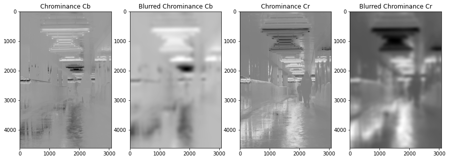

```python
## sigma2 = (50,50) ##

# Gaussian Filter with sd = 50 for both axes
im_filtered_cbcr[:,:,1:] = filters.gaussian(im_ycbcr[:,:,1:], sigma2,
                                            truncate=3.5, multichannel=True)

# Subplots comparing original and blurred image on Cb - Cr channels
plt.subplot(1,4,1); plt.imshow(im_ycbcr[:,:,1], cmap='gray')
plt.title('Chrominance Cb')
plt.subplot(1,4,2); plt.imshow(im_filtered_cbcr[:,:,1], cmap='gray')
plt.title('Blurred Chrominance Cb')
plt.subplot(1,4,3); plt.imshow(im_ycbcr[:,:,2], cmap='gray')
plt.title('Chrominance Cr')
plt.subplot(1,4,4); plt.imshow(im_filtered_cbcr[:,:,2], cmap='gray')
plt.title('Blurred Chrominance Cr')
```

In the last phase of the assignment I proceeded to reconvert the images processed in the previous paragraphs in the RGB color space.

In particular I have selected only the images with $\sigma = 50$ for each paragraph, as the changes applied by the filter are more likely to be observed.

First of all I defined a `colorization(im)` function which, taken as input the modified image and in RGB space, returns an image whose values have been normalized in the $[0,1]$ range and scaled to $255$. Furthermore, the values of the image have been converted from `float64` to `uint8`.

```python
def colorization(im):

  # Data normalization in 0 - 1 and
  # data scaled to 255 with casting to uint8

  im[im > 1.] = 1
  im[im < 0.] = 0
  im = (im * 255).astype(np.uint8)

  return im
```

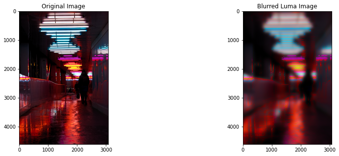

```python
# Conversion from YCbCr to RGB
im1_rgb = color.ycbcr2rgb(im_filtered_y)

# Function application to normalize data
im1_rgb = colorization(im1_rgb)

# Subplots comparing original and new image in RGB
plt.subplot(1,2,1); plt.imshow(im); plt.title('Original Image')
plt.subplot(1,2,2); plt.imshow(im1_rgb); plt.title('Blurred Luma Image')
```

The image filtered on channel Y, as seen previously in grayscale, appears to have undergone the greatest and sharpest distortions compared to its sharpness. Subsequent images, with the filter applied to the chroma channels, appear to have been less distorted.

However, the modified image on both channels at the same time is slightly more distorted and blurry than the other two.

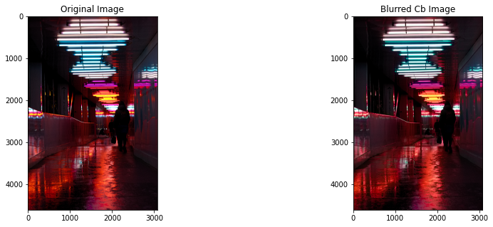

```python
# Conversion from YCbCr to RGB
im2_rgb = color.ycbcr2rgb(im_filtered_cb)

# Function application to normalize data
im2_rgb = colorization(im2_rgb)

# Subplots comparing original and new image in RGB
plt.subplot(1,2,1); plt.imshow(im); plt.title('Original Image')
plt.subplot(1,2,2); plt.imshow(im2_rgb); plt.title('Blurred Cb Image')
```

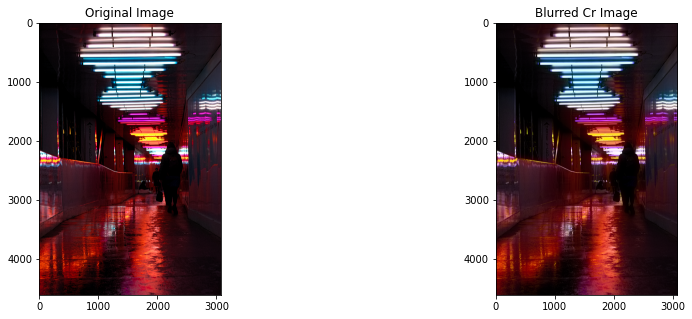

```python
# Conversion from YCbCr to RGB
im3_rgb = color.ycbcr2rgb(im_filtered_cr)

# Function application to normalize data
im3_rgb = colorization(im3_rgb)

# Subplots comparing original and new image in RGB
plt.subplot(1,2,1); plt.imshow(im); plt.title('Original Image')
plt.subplot(1,2,2); plt.imshow(im3_rgb); plt.title('Blurred Cr Image')
```

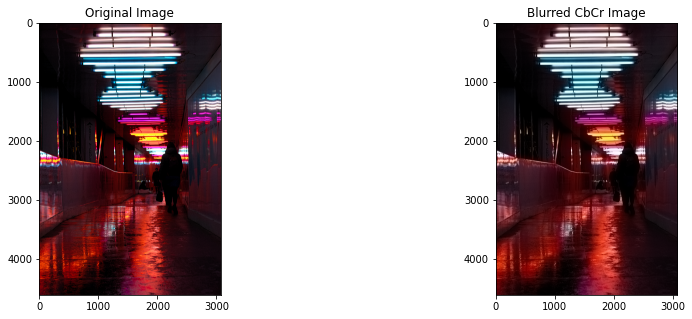

```python
# Conversion from YCbCr to RGB
im4_rgb = color.ycbcr2rgb(im_filtered_cbcr)

# Function application to normalize data
im4_rgb = colorization(im4_rgb)

# Subplots comparing original and new image in RGB
plt.subplot(1,2,1); plt.imshow(im); plt.title('Original Image')
plt.subplot(1,2,2); plt.imshow(im4_rgb); plt.title('Blurred CbCr Image')
```